# stat295_hw2

Furkan Kazancıoğlu - Kemal Doğu Oktay - Sefa Bulut

2024-05-26

# **Stat295 - Hw2**

### *Furkan Kazancıoğlu - 2502185*

### *Kemal Doğu Oktay - 2502250*

### *Sefa Bulut - 2561116*

## **Question 1**

#### Loading the dataset, and explore briefly

```r
df <- read.csv("social_network_ad.csv",sep = ",")
summary(df)
```

```
##        X            User.ID            Gender               Age
##  Min.   :  1.0   Min.   :15566689   Length:400         Min.   :18.00
##  1st Qu.:100.8   1st Qu.:15626764   Class :character   1st Qu.:29.75
##  Median :200.5   Median :15694342   Mode  :character   Median :37.00
##  Mean   :200.5   Mean   :15691540                      Mean   :37.66
##  3rd Qu.:300.2   3rd Qu.:15750363                      3rd Qu.:46.00
##  Max.   :400.0   Max.   :15815236                      Max.   :60.00
##  EstimatedSalary    Purchased        GiftTicket
##  Min.   : 15000   Min.   :0.0000   Min.   :0.0000
##  1st Qu.: 43000   1st Qu.:0.0000   1st Qu.:0.0000
##  Median : 70000   Median :0.0000   Median :1.0000
##  Mean   : 69743   Mean   :0.3575   Mean   :0.7225
##  3rd Qu.: 88000   3rd Qu.:1.0000   3rd Qu.:1.0000
##  Max.   :150000   Max.   :1.0000   Max.   :1.0000
```

```r
head(df)
```

```
##   X  User.ID Gender Age EstimatedSalary Purchased GiftTicket
## 1 1 15624510   Male  19           19000         0          0
## 2 2 15810944   Male  35           20000         0          1
## 3 3 15668575 Female  26           43000         0          0
## 4 4 15603246 Female  27           57000         0          0
## 5 5 15804002   Male  19           76000         0          0
## 6 6 15728773   Male  27           58000         0          0
```

#### Activating the necessary libraries

```r
library(ggplot2)
library(broom)
```

### **Part i**

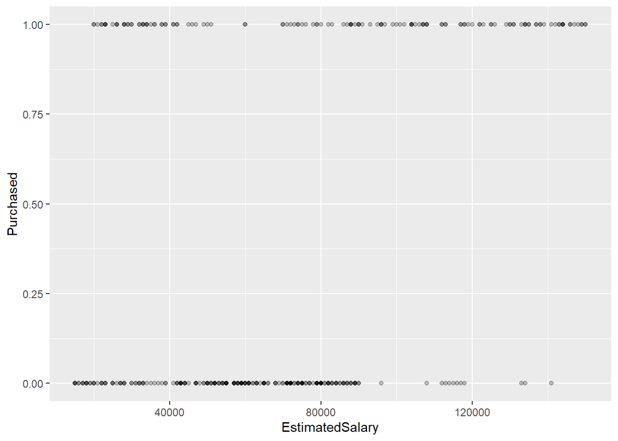

```r
ggplot(df, aes(x = EstimatedSalary, y = Purchased)) +
  geom_point(alpha = 0.25)
```

### **Part ii**

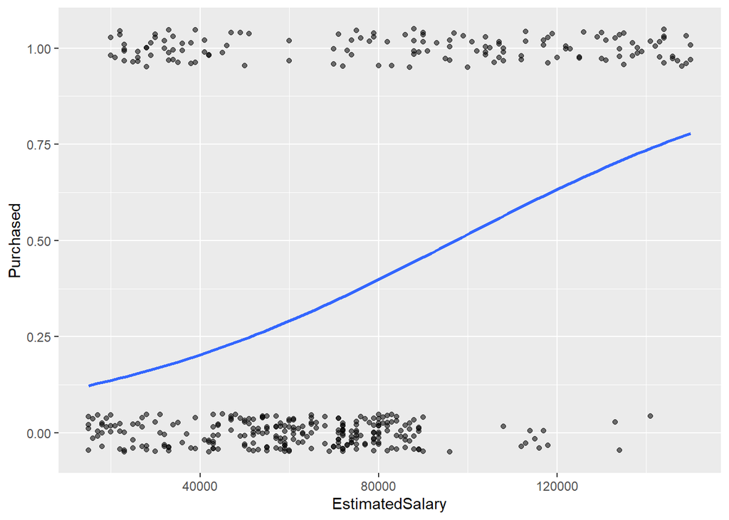

```r
ggplot(df, aes(x = EstimatedSalary, y = Purchased)) +
  geom_jitter(width = 0.52, height = 0.05, alpha = 0.55) +
  geom_smooth(method = "glm", se=FALSE, method.args = list(family = "binomial"))
```

#### By fitting a line, we can interpret that the odds of purchasing a product increase with higher estimated salaries. As the salary continues to increase beyond this range, the probability of purchasing keeps growing, and this suggests a positive correlation between estimated salary and the likelihood of purchasing the product.

```r
model1 <- glm(Purchased ~ EstimatedSalary, data = df, family = binomial())
summary(model1)
```

```
##
## Call:
## glm(formula = Purchased ~ EstimatedSalary, family = binomial(),
##     data = df)
##
## Coefficients:
##                   Estimate Std. Error z value Pr(>|z|)
## (Intercept)     -2.323e+00  2.855e-01  -8.134 4.14e-16 ***
## EstimatedSalary  2.388e-05  3.516e-06   6.790 1.12e-11 ***
## ---
## Signif. codes:  0 '***' 0.001 '**' 0.01 '*' 0.05 '.' 0.1 ' ' 1
##
## (Dispersion parameter for binomial family taken to be 1)
##
##     Null deviance: 521.57  on 399  degrees of freedom
## Residual deviance: 467.73  on 398  degrees of freedom
## AIC: 471.73
##
## Number of Fisher Scoring iterations: 4
```

### **Part iii**

```r
estimated_salary <- 22000
predicted_probability <- predict(model1, newdata = data.frame(EstimatedSalary = estimated_salary), type = "response")
predicted_probability
```

```
##         1
## 0.1421615
```

#### There is a 14.2% chance that an individual with a salary of $22,000 will make a purchase. This suggests that the probability of purchasing increases with higher salaries.

### **Part iv**

```r
df$GenderBinary <- ifelse(df$Gender == "Male", 1, 0)
model2 <- glm(Purchased ~ GenderBinary, data = df, family = binomial())
summary(model2)
```

```
##
## Call:
## glm(formula = Purchased ~ GenderBinary, family = binomial(),
##     data = df)
##
## Coefficients:
##              Estimate Std. Error z value Pr(>|z|)
## (Intercept)   -0.5004     0.1444  -3.464 0.000531 ***
## GenderBinary  -0.1775     0.2091  -0.849 0.395858
## ---
## Signif. codes:  0 '***' 0.001 '**' 0.01 '*' 0.05 '.' 0.1 ' ' 1
##
## (Dispersion parameter for binomial family taken to be 1)
##
##     Null deviance: 521.57  on 399  degrees of freedom
## Residual deviance: 520.85  on 398  degrees of freedom
## AIC: 524.85
##
## Number of Fisher Scoring iterations: 4
```

#### It would normally suggests that males have a lower probability of purchasing compared to females since GenderBinary (B1) is negative. However since it is statistically insignificant, it suggests that there is no significant difference in the probability of purchasing between males and females.

### **Part v**

```r
model3 <- glm(Purchased ~ GiftTicket, data = df, family = binomial())
summary(model3)
```

```
##
## Call:
## glm(formula = Purchased ~ GiftTicket, family = binomial(), data = df)
##
## Coefficients:
##             Estimate Std. Error z value Pr(>|z|)
## (Intercept)  -2.8622     0.4197  -6.819 9.17e-12 ***
## GiftTicket    2.7583     0.4360   6.327 2.50e-10 ***
## ---
## Signif. codes:  0 '***' 0.001 '**' 0.01 '*' 0.05 '.' 0.1 ' ' 1
##
## (Dispersion parameter for binomial family taken to be 1)
##
##     Null deviance: 521.57  on 399  degrees of freedom
## Residual deviance: 446.54  on 398  degrees of freedom
## AIC: 450.54
##
## Number of Fisher Scoring iterations: 5
```

```r
exp(coef(model3))
```

```
## (Intercept)  GiftTicket
##  0.05714286 15.77302629
```

```r
confint(model3)
```

```
##                 2.5 %    97.5 %
## (Intercept) -3.801871 -2.127023
## GiftTicket   1.984041  3.722483
```

```r
tidy(model3, conf.int = TRUE, exponentiate = TRUE)
```

```
## # A tibble: 2 × 7
##   term        estimate std.error statistic  p.value conf.low conf.high
##   <chr>          <dbl>     <dbl>     <dbl>    <dbl>    <dbl>     <dbl>
## 1 (Intercept)   0.0571     0.420     -6.82 9.17e-12   0.0223     0.119
## 2 GiftTicket   15.8        0.436      6.33 2.50e-10   7.27      41.4
```

```r
coefficients <- coef(model3)
beta_0 <- coefficients["(Intercept)"]
beta_1 <- coefficients["GiftTicket"]

cat("log(p / (1 - p)) = ", beta_0, " + ", beta_1, " *GiftTicket\n")
```

```
## log(p / (1 - p)) =  -2.862201  +  2.758301  *GiftTicket
```

#### Since B1 is positive and statistically significant, having a gift ticket increases the likelihood of purchasing.

### **Part vi**

```r
predicted_probabilities <- predict(model3, type = "response")
result3 <- data.frame(GiftTicket = df$GiftTicket, Predicted_Probability = predicted_probabilities)
aggregate_probabilities <- aggregate(Predicted_Probability ~ GiftTicket, data = result3, FUN = mean)
print(aggregate_probabilities)
```

```
##   GiftTicket Predicted_Probability
## 1          0            0.05405405
## 2          1            0.47404844
```

## **Question 2**

#### This is our rshiny app.

```r
# Define required libraries
libraries <- c("ggplot2", "shiny", "tidyverse", "magrittr",
               "dplyr", "rvest", "httr", "readr")

# Load required libraries
lapply(libraries, require, character.only = TRUE)
```

[output not shown]

```r
# Read the dataset
dataset <- read_csv("dataset.csv")
```

```
## ──────────────────────────────────────────────────────── Delimiter: "," chr
## (5): track_id, artists, album_name, track_name, track_genre dbl (15): ...1,
## popularity, duration_ms, danceability, energy, key, loudness... lgl (1):
## explicit
```

```r
summary(dataset)
```

```
##       ...1          track_id           artists           album_name
##  Min.   :     0   Length:114000      Length:114000      Length:114000
##  1st Qu.: 28500   Class :character   Class :character   Class :character
##  Median : 57000   Mode  :character   Mode  :character   Mode  :character
##  Mean   : 57000
##  3rd Qu.: 85499
##  Max.   :113999
##   track_name          popularity      duration_ms       explicit
##  Length:114000      Min.   :  0.00   Min.   :      0   Mode :logical
##  Class :character   1st Qu.: 17.00   1st Qu.: 174066   FALSE:104253
##  Mode  :character   Median : 35.00   Median : 212906   TRUE :9747
##                     Mean   : 33.24   Mean   : 228029
##                     3rd Qu.: 50.00   3rd Qu.: 261506
##                     Max.   :100.00   Max.   :5237295
##   danceability        energy            key            loudness
##  Min.   :0.0000   Min.   :0.0000   Min.   : 0.000   Min.   :-49.531
##  1st Qu.:0.4560   1st Qu.:0.4720   1st Qu.: 2.000   1st Qu.:-10.013
##  Median :0.5800   Median :0.6850   Median : 5.000   Median : -7.004
##  Mean   :0.5668   Mean   :0.6414   Mean   : 5.309   Mean   : -8.259
##  3rd Qu.:0.6950   3rd Qu.:0.8540   3rd Qu.: 8.000   3rd Qu.: -5.003
##  Max.   :0.9850   Max.   :1.0000   Max.   :11.000   Max.   :  4.532
##       mode         speechiness       acousticness    instrumentalness
##  Min.   :0.0000   Min.   :0.00000   Min.   :0.0000   Min.   :0.00e+00
##  1st Qu.:0.0000   1st Qu.:0.03590   1st Qu.:0.0169   1st Qu.:0.00e+00
##  Median :1.0000   Median :0.04890   Median :0.1690   Median :4.16e-05
##  Mean   :0.6376   Mean   :0.08465   Mean   :0.3149   Mean   :1.56e-01
##  3rd Qu.:1.0000   3rd Qu.:0.08450   3rd Qu.:0.5980   3rd Qu.:4.90e-02
##  Max.   :1.0000   Max.   :0.96500   Max.   :0.9960   Max.   :1.00e+00
##     liveness         valence           tempo        time_signature
##  Min.   :0.0000   Min.   :0.0000   Min.   :  0.00   Min.   :0.000
##  1st Qu.:0.0980   1st Qu.:0.2600   1st Qu.: 99.22   1st Qu.:4.000
##  Median :0.1320   Median :0.4640   Median :122.02   Median :4.000
##  Mean   :0.2136   Mean   :0.4741   Mean   :122.15   Mean   :3.904
##  3rd Qu.:0.2730   3rd Qu.:0.6830   3rd Qu.:140.07   3rd Qu.:4.000
##  Max.   :1.0000   Max.   :0.9950   Max.   :243.37   Max.   :5.000
##  track_genre
##  Length:114000
##  Class :character
##  Mode  :character
##
##
##
```

```r
# Define the user interface
ui <- fluidPage(
  titlePanel(
    div(style = "color: #191970; font-weight: bold; font-size: 36px;", "Track Genre Suggestion")
  ),

  sidebarLayout(
    sidebarPanel(
      h3("First: Select Intervals", style = "color: #191970; font-weight: bold;"),
      # Slider inputs for musical attributes
      sliderInput("danceability", "Danceability:", min = 1, max = 100, value = c(30, 70),
                  pre = tags$b(), post = tags$b()),
      sliderInput("loudness", "Loudness:", min = 1, max = 100, value = c(30, 70),
                  pre = tags$b(), post = tags$b()),
      sliderInput("valence", "Valence:", min = 1, max = 100, value = c(30, 70),
                  pre = tags$b(), post = tags$b()),
      sliderInput("tempo", "Tempo:", min = 1, max = 100, value = c(30, 70),
                  pre = tags$b(), post = tags$b()),
      # Button to suggest genres
      actionButton("suggest", "Suggest Genres", style = "background-color: #191970; color: #fff; font-weight: bold;"),

      h3("Second: Select Genre", style = "color: #191970; font-weight: bold;"),
      # Dynamic UI for genre selection
      uiOutput("genre_ui"),
      # Button to suggest tracks
      actionButton("suggest_tracks", "Suggest Tracks", style = "background-color: #191970; color: #fff; font-weight: bold;"),

      h3("Third: Generate Plot", style = "color: #191970; font-weight: bold;"),
      actionButton("generate_plot", "Generate Plot", style = "background-color: #191970; color: #fff; font-weight: bold;")
    ),

    mainPanel(
      h3("Plot of Popular Genres", style = "color: #191970; font-weight: bold;"),
      plotOutput("popularity_plot"),
      h3("Suggested Genres", style = "color: #191970; font-weight: bold;"),
      tableOutput("suggested_genres"),
      h3("Suggested Tracks", style = "color: #191970; font-weight: bold;"),
      tableOutput("suggested_tracks"),

      h3("How to Use the App", style = "color: #191970; font-weight: bold;"),
      # Instructions for using the app
      p("Welcome to the Track Genre Suggestion App! This app helps you discover music genres and tracks based on your preferences for certain musical attributes. Follow the steps below to get started:"),
      # Step 1 instructions
      p(tags$b("Step 1: Select Intervals (Please try to change interval sizes and locations if the app cannot find any genre)")),
      p("On the left sidebar, you'll find sliders that allow you to set your preferred ranges for the following musical attributes:"),
      # Attribute descriptions
      p(tags$b("1. Danceability:"), " This measures how suitable a track is for dancing. It ranges from 1 to 100, where higher values indicate more danceable tracks."),
      p(tags$b("2. Loudness:"), " This represents the overall loudness of a track in decibels, normalized to a range of 1 to 100."),
      p(tags$b("3. Valence:"), " This measures the musical positiveness conveyed by a track. Higher values indicate more positive (happy) tracks."),
      p(tags$b("4. Tempo:"), " This represents the speed or pace of a given piece, measured in beats per minute (BPM), normalized to a range of 1 to 100."),
      p("Adjust the sliders to your desired ranges and click the ", tags$b("Suggest Genres"), " button. The app will suggest the top 5 music genres that match your criteria."),
      # Step 2 instructions
      p(tags$b("Step 2: Select a Genre (Please avoid clicking Suggest Tracks button before Suggest Genres)")),
      p("Once the suggested genres are displayed, you can select one of the genres from the dropdown menu that appears. This selection allows you to further explore tracks within your chosen genre."),
      # Step 3 instructions
      p(tags$b("Step 3: Get Track Suggestions")),
      p("Click the ", tags$b("Suggest Tracks"), " button to get a list of tracks from the selected genre. The tracks are sorted by popularity, showing you the most popular tracks first."),
      p(tags$b("Step 4: Draw a plot")),
      p("Click the ", tags$b("Generate Plot"), " button to get a plot about top 10 track genres by popularity."),
      p("Enjoy exploring and discovering new music tailored to your preferences!")
    )
  )
)
# Define the server logic
server <- function(input, output, session) {

  # Event handler for suggesting genres
  observeEvent(input$suggest, {
    # Normalize data
    normalized_data <- dataset %>%
      mutate(danceability = danceability * 100,
             loudness = scales::rescale(loudness, to = c(1, 100)),
             valence = valence * 100,
             tempo = scales::rescale(tempo, to = c(1, 100)))

    # Filter data based on user input
    filtered_data <- normalized_data %>%
      filter(danceability >= input$danceability[1], danceability <= input$danceability[2],
             loudness >= input$loudness[1], loudness <= input$loudness[2],
             valence >= input$valence[1], valence <= input$valence[2],
             tempo >= input$tempo[1], tempo <= input$tempo[2])

    # Compute suggested genres
    suggested_genres <- filtered_data %>%
      group_by(track_genre) %>%
      summarize(count = n()) %>%
      arrange(desc(count)) %>%
      head(5) %>%
      mutate(track_genre = str_replace_all(track_genre, "_", " "))

    # Render suggested genres table
    output$suggested_genres <- renderTable({
      suggested_genres
    })

    # Render genre selection dropdown
    output$genre_ui <- renderUI({
      selectInput("selected_genre", "Select Genre:", choices = paste0(suggested_genres$track_genre, " (", suggested_genres$count, ")"))
    })
  })

  # Event handler for suggesting tracks
  observeEvent(input$suggest_tracks, {
    req(input$selected_genre)

    selected_genre <- gsub(" \\(.*\\)$", "", input$selected_genre)

    # Songs that fit the user's range and filtered by selected genre
    normalized_data <- dataset %>%
      mutate(danceability = danceability * 100,
             loudness = scales::rescale(loudness, to = c(1, 100)),
             valence = valence * 100,
             tempo = scales::rescale(tempo, to = c(1, 100)))

    # Filter tracks based on selected genre
    filtered_tracks <- normalized_data %>%
      filter(track_genre == selected_genre,
             danceability >= input$danceability[1], danceability <= input$danceability[2],
             loudness >= input$loudness[1], loudness <= input$loudness[2],
             valence >= input$valence[1], valence <= input$valence[2],
             tempo >= input$tempo[1], tempo <= input$tempo[2]) %>%
      arrange(desc(popularity))

    # Render suggested tracks table
    output$suggested_tracks <- renderTable({
      filtered_tracks %>%
        select(track_name, artists, popularity) %>%
        mutate(track_name = str_replace_all(track_name, "_", " "),
               artists = str_replace_all(artists, "_", " "))
    })
  })
  # Codes for making plot
  output$popularity_plot <- renderPlot({
    ggplot(data.frame(x = c(0, 1), y = c(0, 1)), aes(x, y)) +
      geom_blank() +
      theme_void() +
      annotate("text", x = 0.5, y = 0.5, label = "Click the Generate Plot Button", size = 8, color = "black" )
  })

  observeEvent(input$generate_plot, {
    top_genres <- dataset %>%
      group_by(track_genre) %>%
      summarize(total_popularity = sum(popularity, na.rm = TRUE)) %>%
      arrange(desc(total_popularity)) %>%
      head(10) %>%
      mutate(track_genre = str_replace_all(track_genre, "_", " "))

    output$popularity_plot <- renderPlot({
      ggplot(top_genres, aes(x = total_popularity, y = reorder(track_genre, -total_popularity))) +
        geom_bar(stat = "identity", fill = "#191970") +
        coord_flip() +
        theme_minimal() +
        labs(title = "Top 10 Track Genres by Popularity",
             x = "Track Genre",
             y = "Total Popularity") +
        theme(axis.text.x = element_text(angle = 0, hjust = 1))
    })
  })
}
# Run the Shiny app
shinyApp(ui = ui, server=server)
```

Shiny applications not supported in static R Markdown documents